# Regression Accuracy

Dr. Josh Jacobson

12 January 2026

*These lecture notes are adapted from materials originally developed by Dr. Kris Pruitt.*

The purpose of this lesson is to compute and explain the primary metrics for assessing the prediction accuracy of a regression model. Specifically, we explore root mean squared error (RMSE) for training and testing sets.

# Training versus Testing Data

When evaluating the accuracy of a predictive model, it is important to distinguish between training and testing data. Training data is used to estimate the functional relationship between the response and the predictor variables. Testing data is then applied to determine the accuracy of the estimated model. It is important that we do *not* measure a model’s accuracy using the same data that trained it. Otherwise, we are likely to overestimate the model’s accuracy. One analogy to this situation is giving students the answers prior to an exam. The students may perform well on those particular questions, but that does not mean they truly understand the material.

A common method for obtaining training and testing data is to randomly divide a sample into the two sets. We discuss various methodologies for performing this split later in the course. For now, let’s assume we prefer to divide our data into 75% training and 25% testing. Let’s demonstrate this process in an example. Import and review the file `fish.csv`, which is available on the course website. The data includes various measurements of fish caught in a Finnish lake in 1917.

```r
# import fish data
fish <- read_csv("fish.csv")

# display data structure
glimpse(fish)
```

```
## Rows: 142
## Columns: 7
## $ Species <chr> "Bream", "Bream", "Bream", "Bream", "Bream", "Bream", "Bream",…
## $ Weight  <dbl> 242, 290, 340, 363, 430, 450, 500, 390, 450, 500, 475, 500, 50…
## $ Length1 <dbl> 23.2, 24.0, 23.9, 26.3, 26.5, 26.8, 26.8, 27.6, 27.6, 28.5, 28…
## $ Length2 <dbl> 25.4, 26.3, 26.5, 29.0, 29.0, 29.7, 29.7, 30.0, 30.0, 30.7, 31…
## $ Length3 <dbl> 30.0, 31.2, 31.1, 33.5, 34.0, 34.7, 34.5, 35.0, 35.1, 36.2, 36…
## $ Height  <dbl> 11.5200, 12.4800, 12.3778, 12.7300, 12.4440, 13.6024, 14.1795,…
## $ Width   <dbl> 4.0200, 4.3056, 4.6961, 4.4555, 5.1340, 4.9274, 5.2785, 4.6900…
```

Our goal is to predict a fish’s body weight (grams) based on its length (centimeters). We will use `Length3` which measures from the fish’s nose to the end of its tail. Prior to any analysis, we randomly split the sample such that 106 (75%) fish are used for training and the remaining 36 (25%) fish are used for testing.

```r
# set randomization seed
set.seed(45)

# randomly select training rows
rows <- sample(x = 1:142, size = 106, replace = FALSE)

# extract training and testing sets
training <- fish[rows, ]
testing <- fish[-rows, ]
```

Ideally, the two sets are each representative of the population from which the sample was collected. At the very least, the mean response should be similar. We can easily check this by summarizing the two sets.

```r
# compute mean response

mean(training$Weight)
```

```
## [1] 360.8226
```

```r
mean(testing$Weight)
```

```
## [1] 357.4639
```

```r
sd(training$Weight)
```

```
## [1] 311.9595
```

```r
sd(testing$Weight)
```

```
## [1] 345.0904
```

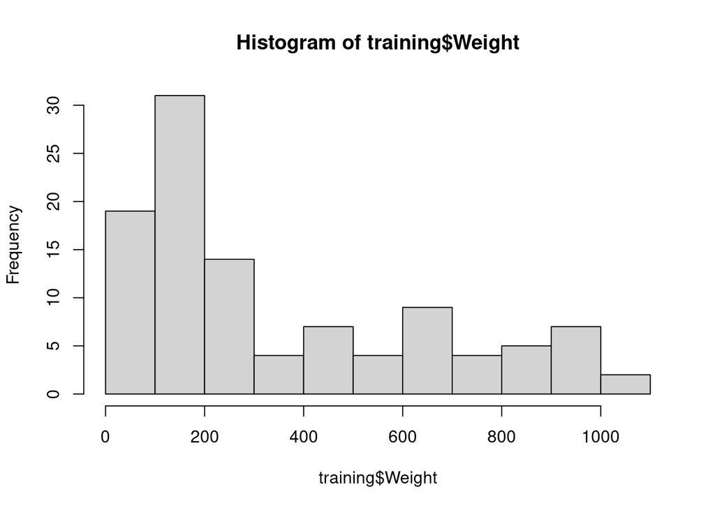

```r
hist(training$Weight)
```

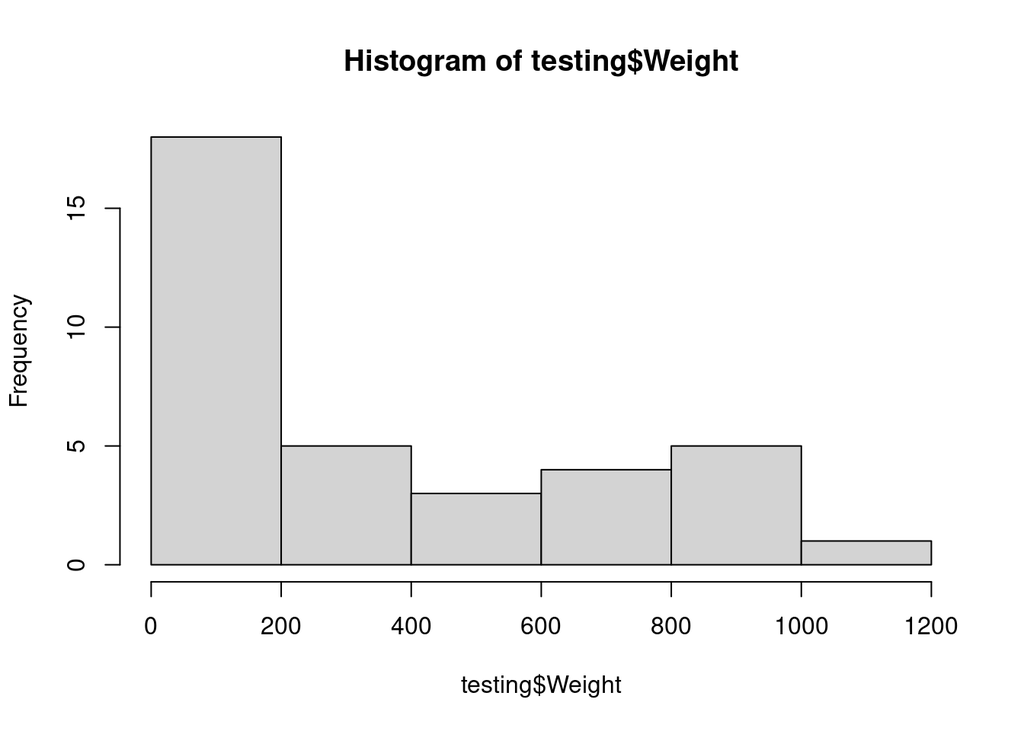

```r
hist(testing$Weight)
```

For small sample sizes, it is unreasonable to expect the means to be *exactly* the same. But they should be close enough to provide some evidence that the two sets are similarly distributed. With the sample appropriately split, we are ready to construct and evaluate a model.

# Regression Models

Let’s depict the association between a fish’s length and weight in a scatter plot. We base this purely on the training data. The testing data is held back until we are ready to measure accuracy.

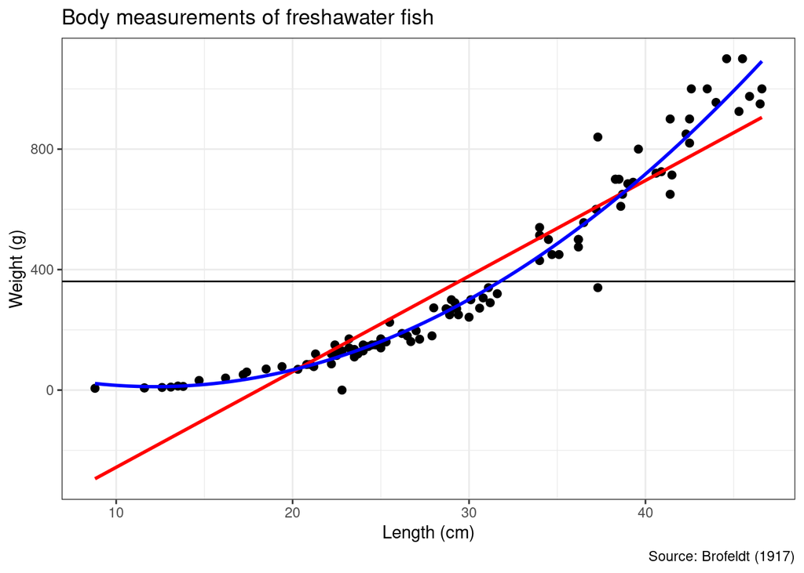

```r
# create scatter plot
ggplot(data = training, aes(x = Length3, y = Weight)) +
  geom_point(size = 2) +
  geom_hline(yintercept = mean(training$Weight), color = 'black') +
  geom_smooth(formula = y~x, method = 'lm', se = FALSE, color = 'red') +
  geom_smooth(formula = y~poly(x,2), method = 'lm', se = FALSE, color = 'blue') +
  labs(title = 'Body measurements of freshawater fish', x = 'Length (cm)', y = 'Weight (g)', caption = 'Source: Brofeldt (1917)') +
  theme_bw()
```

The graphic depicts three different regression models we might choose to employ. The horizontal black line represents the average weight of all fish in the training set. In other words, we could simply guess the average weight for all fish, regardless of length.

$$y=360.823$$

The second model (red line) assumes a linear relationship between the two variables and determines the best fit. We will learn how to find this linear equation very soon, but for know let’s assume we are given the equation below.

$$y=31.737x-573.666$$

Finally, the third model (blue curve) assumes a quadratic relationship between length and weight. As with the linear equation, assume we are given the polynomial equation below.

$$y=0.912x^2-22.233x+146.857$$

Based purely on a visual assessment, which of these three models do we expect to perform the best? In other words, which model most accurately represents the relationship between length and weight? In a sense, an accurate model should be “close” to most of the points in the scatter plot. By this measure, the quadratic model seems best. However, we do not need to guess from a visual graphic. We can use the objective metric presented in the next section.

# Root Mean Squared Error

Now we want to assess the accuracy of each model using the testing data. For a continuous response variable, a popular metric is the root mean squared error (RMSE). For a testing set with $n$ observations, let $y_i$ be the true response value for the $i$th observation and $\hat{y}_i$ be the predicted value. Then the RMSE is calculated as follows.

$$\text{RMSE}=\sqrt{\frac{\sum_i (y_i-\hat{y}_i)^2}{n}}$$

The metric is calculated exactly as the name implies. First we compute the error $y_i-\hat{y}_i$ for each observation in the testing set. Then we square those errors. The mean is calculated by adding up all of the squared errors and dividing by the observations $n$. Finally, we take the square root in order to return the accuracy to the same units as the response variable. A relatively small RMSE suggests predictions that are close to the actual values, on average, and thus an accurate model. Let’s compute RMSE for our fish models.

```r
# predict weight using each model
fish_predict <- testing %>%
  mutate(
    Weight_avg = 360.823,
    Weight_lin = 31.737 * Length3 - 573.666,
    Weight_poly = 0.912 * Length3^2 - 22.233 * Length3 + 146.857
  )

# compute RMSE for all models
fish_predict %>%
  summarize(
    RMSE_avg = sqrt(mean((Weight - Weight_avg)^2)),
    RMSE_lin = sqrt(mean((Weight - Weight_lin)^2)),
    RMSE_non = sqrt(mean((Weight - Weight_poly)^2))
  )
```

| RMSE_avg | RMSE_lin | RMSE_non |
| --- | --- | --- |
| 340.2803 | 116.948 | 51.38388 |

Which model predicts the weight of fish more accurately? Does that align with the what we observed in the scatter plot? Why not use mean absolute error?